# Neural Predictive Modeling of Trial Outcomes Based on Visual Stimuli in Mice

Andrew Cao 918156389

2024-02-25

## Abstract:

This project analyzes a subset data collected by Steinmetz and colleagues. (2019) from 39 sessions of experiments performed on 10 mice. Our analysis focuses on 18 sessions of four mice: Cori Forssman Hence Lederberg. We begin by exploring data structures in the 18 sessions. Then we examine neural activity and changes in each trial, and assess homogeneity or heterogeneity between sessions and mice. To integrate the data using benchmark methods, we extract patterns that are common across sessions. We then build a model using logistic regression based on integrated data. This project is designed to provide insights into the relationship between brain activity and decision-making.

## Section 1 Introduction:

This project is aimed at developing a model to predict accurately the outcome of trials using data on neural activity and visual stimuli. The dataset is a subset from recordings taken during experiments by Steinmetz and colleagues. (2019) on ten mice in 39 sessions. We will analyze 18 sessions of four mice, Cori, Frossman Hence and Lederberg.

In each trial, visual stimuli of varying contrast levels were presented on two screens located next to the mice. The contrast levels were 0, 0.25, 1, or 0, with 0 being no stimulus. These stimuli were used to make decisions by the mice using a wheel that was controlled by their forepaws. The mice were given feedback based on the wheel-turning behaviors.

Spike trains were recorded as the neural activity of the mouse’s visual cortex. The spike trains will be examined from the stimulus onset until 0.4 seconds after onset. Key variables include: $feedback type$ : Type of feedback provided to the mice. 1 represents success, and -1 failure. $contrast left$ : Contrast of the left stimulus. $contrast right$ : Contrast of the right stimuli. time : Centers of the time bins used to record spike train data. $spks$ Number of spikes from neurons recorded in the visual cortex for each time bin. brain_area is the area of the cortex where each neuron is situated.

This project will be divided into four part: exploratory analysis,data integration, model training, and predictive modeling. In part 1, we will perform exploratory data analyses to describe data structures across sessions. We will also examine neural activity during trials, explore differences across trials, as well as assess homogeneity or heterogeneity between sessions and mice. This analysis will give us insights into the characteristics of the data and patterns to us to pick the information we interest.

The second part will be devoted to data integration. We will present methods for combining data from different trials. It may be necessary to identify patterns that are common across sessions, or to account for differences in sessions. Our goal is to use the information available from multiple sessions to improve the performance of our prediction model.

##Section 2 Exploratiry Analysis

Within this data set are 18 distinct sessions which feature experiments conducted on four distinct mice. Each session includes a different number of trials. Trials taken place during every session with no missing values being reported and success rate being the ratio between successful trials relative to total trials taken place in any session. It should be noted that this data set is complete, with no missing values for any variable mentioned herein.

| mouse_name | date_exp | n_brain_area | n_neurons | n_trials | success_rate |
| --- | --- | --- | --- | --- | --- |
| Cori | 2016-12-14 | 8 | 734 | 114 | 0.61 |
| Cori | 2016-12-17 | 5 | 1070 | 251 | 0.63 |
| Cori | 2016-12-18 | 11 | 619 | 228 | 0.66 |
| Forssmann | 2017-11-01 | 11 | 1769 | 249 | 0.67 |
| Forssmann | 2017-11-02 | 10 | 1077 | 254 | 0.66 |
| Forssmann | 2017-11-04 | 5 | 1169 | 290 | 0.74 |
| Forssmann | 2017-11-05 | 8 | 584 | 252 | 0.67 |
| Hench | 2017-06-15 | 15 | 1157 | 250 | 0.64 |
| Hench | 2017-06-16 | 12 | 788 | 372 | 0.69 |
| Hench | 2017-06-17 | 13 | 1172 | 447 | 0.62 |
| Hench | 2017-06-18 | 6 | 857 | 342 | 0.80 |
| Lederberg | 2017-12-05 | 12 | 698 | 340 | 0.74 |
| Lederberg | 2017-12-06 | 15 | 983 | 300 | 0.80 |
| Lederberg | 2017-12-07 | 10 | 756 | 268 | 0.69 |
| Lederberg | 2017-12-08 | 8 | 743 | 404 | 0.76 |
| Lederberg | 2017-12-09 | 6 | 474 | 280 | 0.72 |
| Lederberg | 2017-12-10 | 6 | 565 | 224 | 0.83 |
| Lederberg | 2017-12-11 | 10 | 1090 | 216 | 0.81 |

The data set under consideration contains six key variables: “mouse_name” identifies which mice participated in each session; “date_exp” is when an experiment took place; “n_brain_area” is the count of distinct brain areas examined, while neurons recorded. “n_neurons” depicts the total number of neurons which were observed or measured during an experiment on any given date, or recorded or analyzed during its conduct. It reflects a count of individual nerve cells observed or measured. “n_Trials” displays the total number of trials completed during an experiment. A trial represents either an instance of performing an experiment or repeated measurements under identical conditions. “Success_rate” refers to the proportion of trials that were successful, calculated as the ratio between successful trials and total number of trials; usually expressed either as a percentage or decimal; here it appears as decimals (0.61 represents 61% success rate).

At our data processing, we examined neural activities recorded during each experimental trial to discover potential predictors of success rate. By analyzing spike data across various brain regions and reviewing trial-specific conditions like visual contrast levels, we attempted to establish which neural patterns may reliably predict successful outcomes. This detailed process involved looking at both sum and mean spike activity as well as visual contrast levels as ways to establish links between neural activity and behavioral performance metrics.

```
## # A tibble: 8 × 8
##   brain_area region_sum_spike region_count region_mean_spike trail_id
##   <chr>                 <dbl>        <int>             <dbl>    <dbl>
## 1 ACA                      64          109             0.587        2
## 2 CA3                     116           68             1.71         2
## 3 DG                       53           34             1.56         2
## 4 LS                      190          139             1.37         2
## 5 MOs                      88          113             0.779        2
## 6 SUB                     146           75             1.95         2
## 7 VISp                    294          178             1.65         2
## 8 root                     12           18             0.667        2
## # ℹ 3 more variables: contrast_left <dbl>, contrast_right <dbl>,
## #   feedback_type <dbl>
```

This table presents neural recordings from a neuroscience experiment, showing activity in various brain areas such as the ACA, CA3, and DG. The “region_sum_spike” column tallies the total spikes–which measures neuron action potentials–in each region; “Region_count” represents observations or neurons recorded; “region_mean_spike” shows average spike counts per observation while “Trial id” displays trial ID number while the “contrast left/contrast right” columns may indicate visual contrast in stimuli presented during trials which indicates no contrast (control condition); finally “feedback_type” provides uniform feedback across rows indicating which kind of feedback type (ie “control condition).

```r
session_1 <- get_session_data(1)
head(session_1)
```

```
## # A tibble: 6 × 11
##   brain_area region_sum_spike region_count region_mean_spike trail_id
##   <chr>                 <dbl>        <int>             <dbl>    <int>
## 1 ACA                     138          109             1.27         1
## 2 CA3                     104           68             1.53         1
## 3 DG                       79           34             2.32         1
## 4 LS                      269          139             1.94         1
## 5 MOs                     106          113             0.938        1
## 6 SUB                     156           75             2.08         1
## # ℹ 6 more variables: contrast_left <dbl>, contrast_right <dbl>,
## #   feedback_type <dbl>, mouse_name <chr>, date_exp <chr>, session_id <dbl>
```

```r
session_18 <- get_session_data(18)
head(session_18)
```

```
## # A tibble: 6 × 11
##   brain_area region_sum_spike region_count region_mean_spike trail_id
##   <chr>                 <dbl>        <int>             <dbl>    <int>
## 1 ACB                     197          155             1.27         1
## 2 CA3                      57           35             1.63         1
## 3 CP                      179          158             1.13         1
## 4 LGd                      70           89             0.787        1
## 5 OT                       22           26             0.846        1
## 6 SI                       89           48             1.85         1
## # ℹ 6 more variables: contrast_left <dbl>, contrast_right <dbl>,
## #   feedback_type <dbl>, mouse_name <chr>, date_exp <chr>, session_id <dbl>
```

Benchmark Method 2 analysis has allowed us to identify variables that may impact success rate and brain areas that play a part in it, with particular attention paid to sessions 1-18 and its various trials, respectively. A key challenge has been the wide variance in brain region representation across sessions and trials; therefore requiring us to employ a nuanced approach in order to reconcile any disparate representation and identify patterns contributing to positive results.

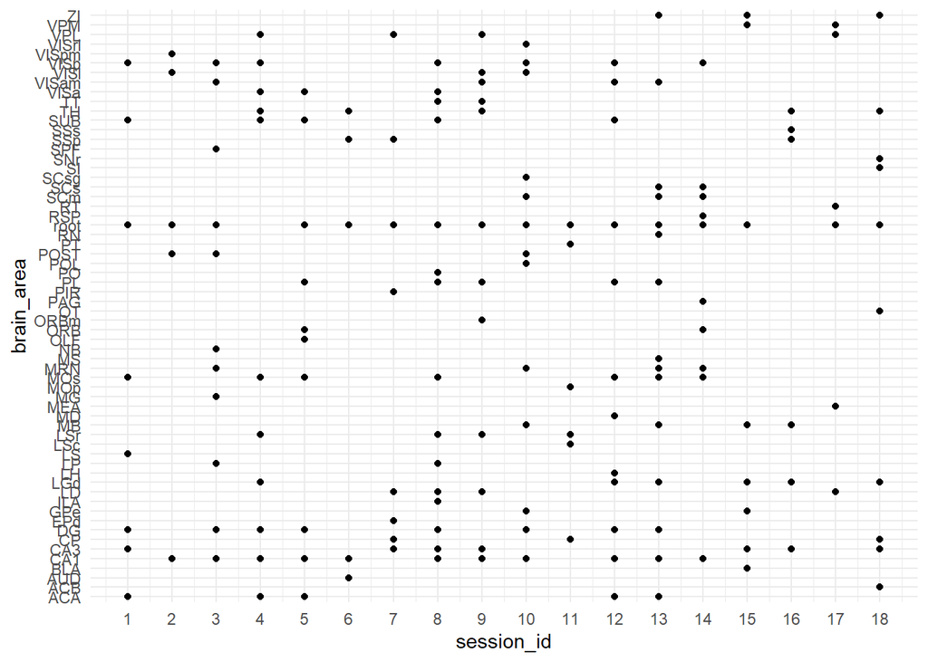

```r
area = c()
for(i in 1:n.session){
    tmp = session[[i]];
    area = c(area, unique(tmp$brain_area))
}

area = unique(area)
length(area)
```

```
## [1] 62
```

From the graph, we are curious about the the total level in brain area. From the program, there are 62 levels in brain area

Subsequently, we began exploring trial-to-trial variations by studying their dynamics; specifically observing interactions between success rate and mean spike activity. The purpose of this phase of research is to understand the intricate relationship between neural response patterns and task performance success.

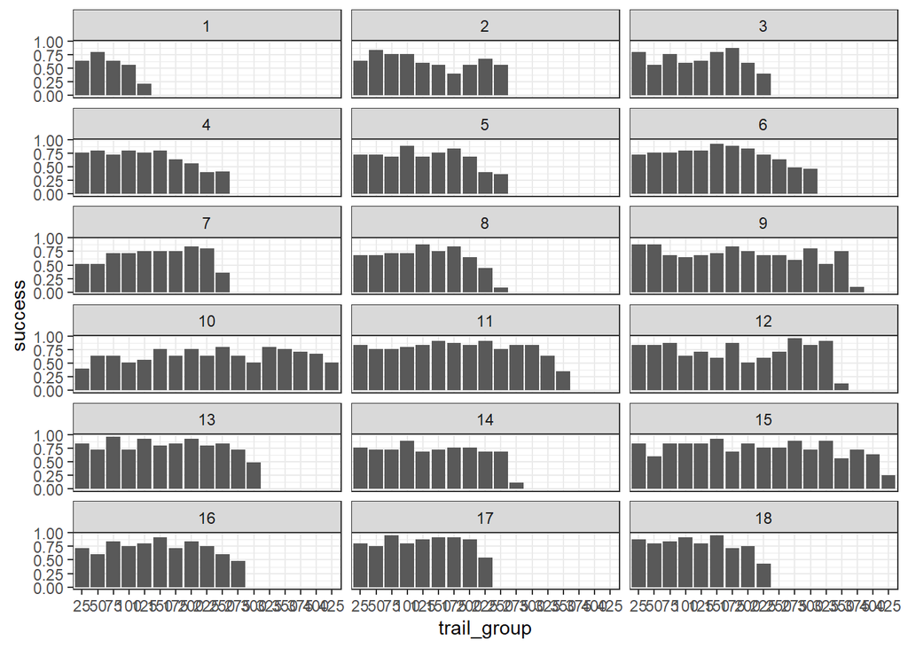

The graph shows the success rate for trials in 18 sessions divided into 25 trial bins. Each subplot represents a session and shows the rise and fall of the success rate over the course of the trials.

```
## # A tibble: 18 × 2
##    session_id success_rate
##    <fct>             <dbl>
##  1 1                 0.605
##  2 2                 0.633
##  3 3                 0.662
##  4 4                 0.667
##  5 5                 0.661
##  6 6                 0.741
##  7 7                 0.671
##  8 8                 0.644
##  9 9                 0.685
## 10 10                0.620
## 11 11                0.795
## 12 12                0.738
## 13 13                0.797
## 14 14                0.694
## 15 15                0.765
## 16 16                0.718
## 17 17                0.830
## 18 18                0.806
```

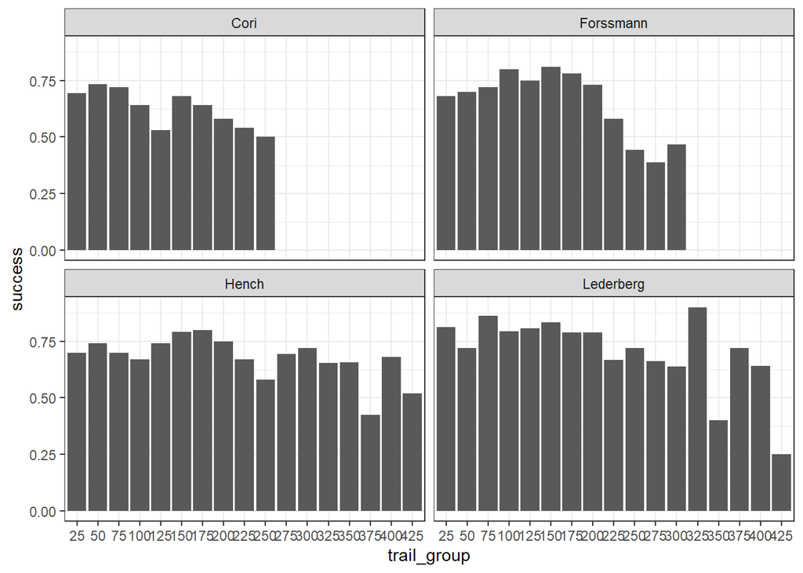

The Graph was divided into four categories: Cori, Forssmann,Hench, and Lederberg.In the graph, initially, a trend upward is seen, suggesting that the mice are improving and adapting to the task. As the trials continue, however, there is a noticeable decline in success rates, which may indicate fatigue or reduced engagement. The variation in the number trials between sessions could be due to the different endurance levels of the mice or their engagement with the experiment.

```
## # A tibble: 4 × 2
##   mouse_name success_rate
##   <chr>             <dbl>
## 1 Cori              0.639
## 2 Forssmann         0.687
## 3 Hench             0.684
## 4 Lederberg         0.761
```

The table depicted above quantifies the success rates for individual mice, facilitating an easier observation of variability in performance tolerance among the subjects.

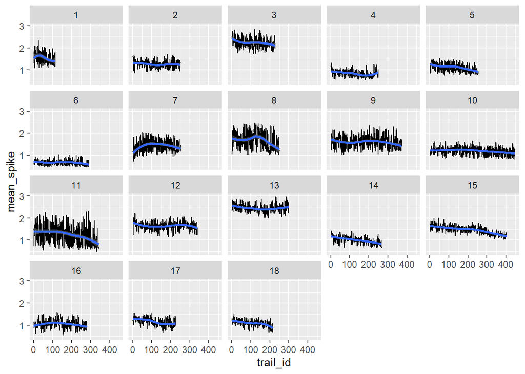

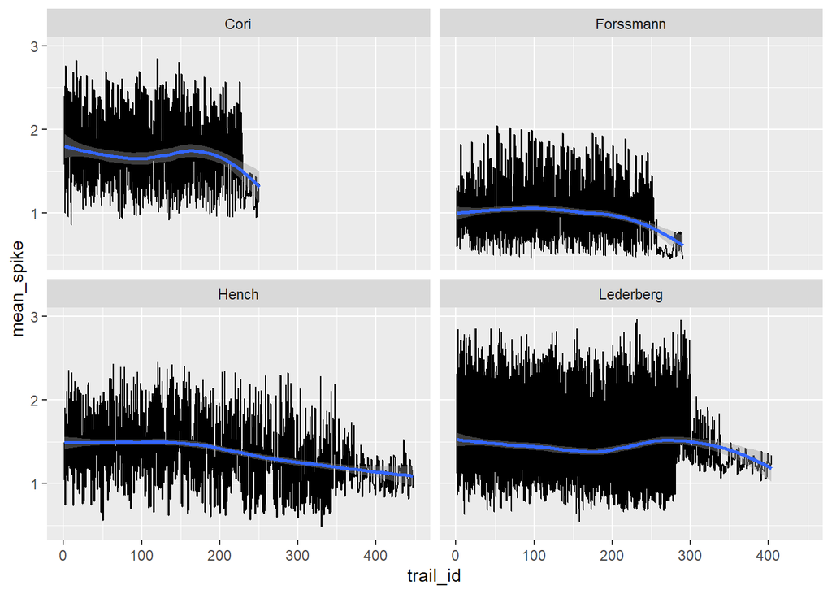

“mean_spike” by Cori, Forssmann,Hench, and Lederberg also shows a same trending with the last graph. This further confirm our assumption

Furthermo, we aimed to determine the average success rate across the entirety of the experiment to gauge overall performance.

```r
# feedback_type
n.session=length(session)

n_success = 0
n_trial = 0
for(i in 1:n.session){
    tmp = session[[i]];
    n_trial = n_trial + length(tmp$feedback_type);
    n_success = n_success + sum(tmp$feedback_type == 1);
}
n_success/n_trial
```

```
## [1] 0.7100964
```

From the programming output, we can see over 71 % trials are success. This indicates that a majority of the trails across all sessions ended in success.

Summary of Features feedback_type: Numerous instances indicate success, but potential issues may exist. contrast_left and contrast_right: Present in four distinct scenarios. In particular, When left contrast > right contrast, success (1) if turning the wheel to the right and failure (-1) otherwise. When right contrast > left contrast, success (1) if turning the wheel to the left and failure (-1) otherwise. When both left and right contrasts are zero, success (1) if holding the wheel still and failure (-1) otherwise. When left and right contrasts are equal but non-zero, left or right will be randomly chosen (50%) as the correct choice. mouse_name: Influenced by four factors. date_exp: May not be directly correlated with success. brain_area: Comprised of multiple factors; consideration for reduction to a smaller set of factors may be beneficial. spks: Matrix of dimensions $p_i * q_i$ across session $i$ for number of trials $N_i$. time:Vector of dimension q across sessions for number of trials $N_i$.

##Section 3 Data Integration

Based on the Benchmark Method, we extract the data from session 18, then combine them into one data.Given that there is only one mouse involved, the mouse_name feature is omitted. The information of contrast_left and contrast_right are summarized into four factors in decision according to the scenrio because a same behavior in different scenrio results in different feedback_type. We employ benchmark method 1, which involves summarizing brain_area, spks, and time into a single number by averaging over spks. Then we transform the integrated data into our predictive_feature.

```
##  feedback_type decision   avg_spikes
##  -1: 42        1:72     Min.   :0.6872
##  1 :174        2:71     1st Qu.:1.0055
##                3:63     Median :1.1050
##                4:10     Mean   :1.0964
##                         3rd Qu.:1.2060
##                         Max.   :1.5284
```

This R code snippet uses transformed data to examine neural activity. It categorizes decisions based on contrast levels between left and right stimuli and calculates average neural spike counts per trial; four possible outcomes of which correspond with subject responses at various contrast levels are also encoded within its decision logic; this output shows distributions of feedback types for these decisions as well as descriptive statistics of neural spikes recorded - negative feedback being less frequent and 1 and 4 being associated with extreme outcomes - thus the average spike count seems to hover around one, although with some variations across trials; these findings should help uncover some insights into subject responses at various contrast levels as well as analyse neural activity within subjects’ responses in different settings.

##Section 4 Predictive modeling

In our predictive model, we choose to use Logistic regression Model to do the prediction.In this section, we apply 3 different models to observe which outputs a most optimal result. Firstly, we apply the model 1 with data from session 18.

```r
set.seed(101)
sample <- sample.int(n = n_obs, size = floor(.8 * n_obs), replace = F)
train <- dat[sample, ]
test  <- dat[-sample, ]
fit1 <- glm(feedback_type~., data = train, family="binomial")
summary(fit1)
```

```
##
## Call:
## glm(formula = feedback_type ~ ., family = "binomial", data = train)
##
## Coefficients:
##             Estimate Std. Error z value Pr(>|z|)
## (Intercept)  -3.1945     1.5730  -2.031  0.04227 *
## decision2    -0.2750     0.6230  -0.441  0.65892
## decision3    -0.7646     0.5300  -1.443  0.14915
## decision4    -3.1867     0.8569  -3.719  0.00020 ***
## avg_spikes    4.9317     1.5257   3.232  0.00123 **
## ---
## Signif. codes:  0 '***' 0.001 '**' 0.01 '*' 0.05 '.' 0.1 ' ' 1
##
## (Dispersion parameter for binomial family taken to be 1)
##
##     Null deviance: 165.27  on 171  degrees of freedom
## Residual deviance: 137.34  on 167  degrees of freedom
## AIC: 147.34
##
## Number of Fisher Scoring iterations: 5
```

```r
pred1 <- predict(fit1, test %>% select(-feedback_type), type = 'response')
prediction1 <- factor(pred1 > 0.5, labels = c('-1', '1'))
mean(prediction1 != test$feedback_type)
```

```
## [1] 0.2272727
```

In prediction 1, we use the model’s predicted probability to make a prediction. The prediction error on the test data set is about 22%.

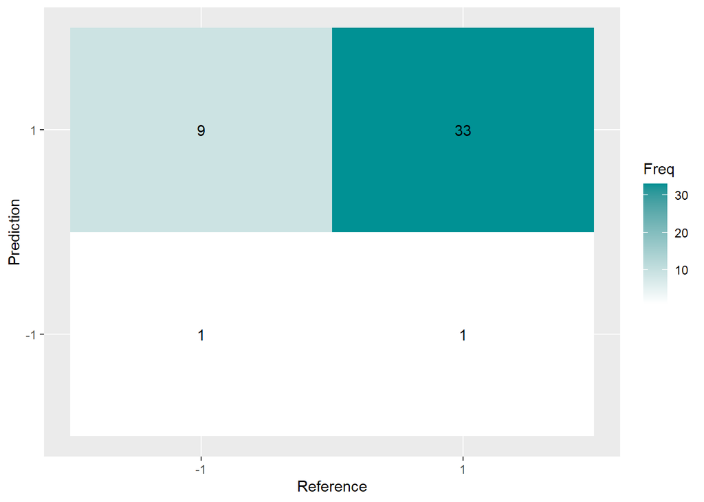

```
## [1] 0.2272727
```

In prediction 0, the prediction error on the test data is 22%. This indicates that the prediction is not doing well because if we just bias to success completely, we get same error rate.

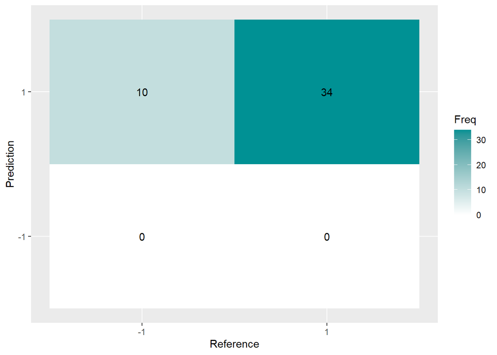

Confusion matrix from biased guess.

From model2, we apply EDA of the average number of spikes per neuron in each brain area. This summarize “brain_area”,“spks”, and “time”, which to average number of spikes per neuron in each brain area.

```
## # A tibble: 6 × 12
##   feedback_type decision    CP   ACB    OT    SI   SNr   LGd    ZI   CA3  root
##   <fct>         <fct>    <dbl> <dbl> <dbl> <dbl> <dbl> <dbl> <dbl> <dbl> <dbl>
## 1 1             1        1.27  1.63  1.13  0.787 0.846  2.08  1.85 0.8    1.06
## 2 1             1        1.16  1.4   1.12  1.04  0.577  1.86  2.19 1.06   1.41
## 3 -1            3        0.723 1.43  0.943 1.25  0.538  1.92  1.52 0.923  1.24
## 4 -1            3        0.890 0.829 0.652 1.16  0.423  1.65  1.81 0.815  1.02
## 5 1             3        0.729 1.26  0.582 0.989 0.346  2.36  1.67 0.885  1.36
## 6 1             1        0.981 1.43  0.810 0.719 0.808  1.94  1.96 0.823  1.25
## # ℹ 1 more variable: TH <dbl>
```

```
##
## Call:
## glm(formula = feedback_type ~ ., family = "binomial", data = train)
##
## Coefficients:
##             Estimate Std. Error z value Pr(>|z|)
## (Intercept)  -1.8890     2.2237  -0.849 0.395618
## decision2    -0.2538     0.7222  -0.351 0.725250
## decision3    -1.4426     0.6522  -2.212 0.026982 *
## decision4    -3.6987     0.9971  -3.710 0.000208 ***
## CP            3.7749     2.5070   1.506 0.132144
## ACB          -0.3608     0.6038  -0.598 0.550105
## OT            1.8254     2.1131   0.864 0.387668
## SI            1.5682     1.0881   1.441 0.149503
## SNr          -1.7827     0.9467  -1.883 0.059700 .
## LGd           2.2555     1.2566   1.795 0.072671 .
## ZI           -2.8712     1.1066  -2.595 0.009473 **
## CA3           2.5892     1.3209   1.960 0.049967 *
## root          1.5494     1.6697   0.928 0.353443
## TH           -3.3211     1.6903  -1.965 0.049441 *
## ---
## Signif. codes:  0 '***' 0.001 '**' 0.01 '*' 0.05 '.' 0.1 ' ' 1
##
## (Dispersion parameter for binomial family taken to be 1)
##
##     Null deviance: 165.27  on 171  degrees of freedom
## Residual deviance: 118.94  on 158  degrees of freedom
## AIC: 146.94
##
## Number of Fisher Scoring iterations: 6
```

```r
pred2 <- predict(fit2, test %>% select(-feedback_type), type = 'response')
prediction2 <- factor(pred2 > 0.5, labels = c('-1', '1'))
mean(prediction2 != test$feedback_type)
```

```
## [1] 0.25
```

In model2, we use the same computation with model 1, but the test data has been trained differently. The prediction error on the test data is 25%.

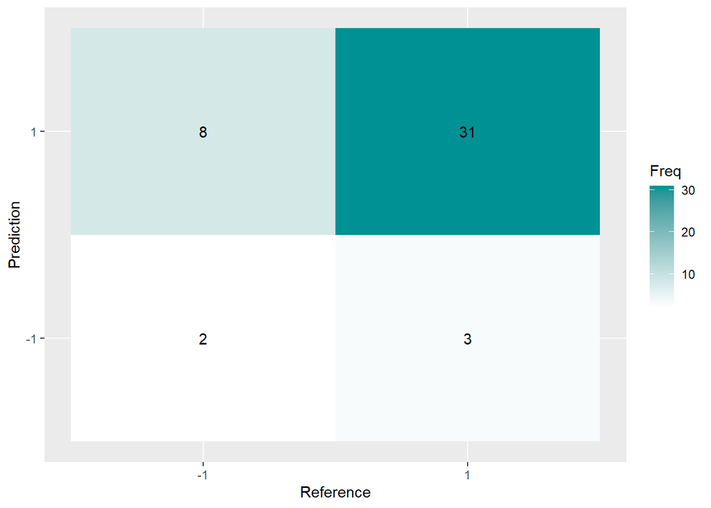

It appears that the model predicts more failures compared to the previous one. However, its performance in predicting failures is not particularly strong.

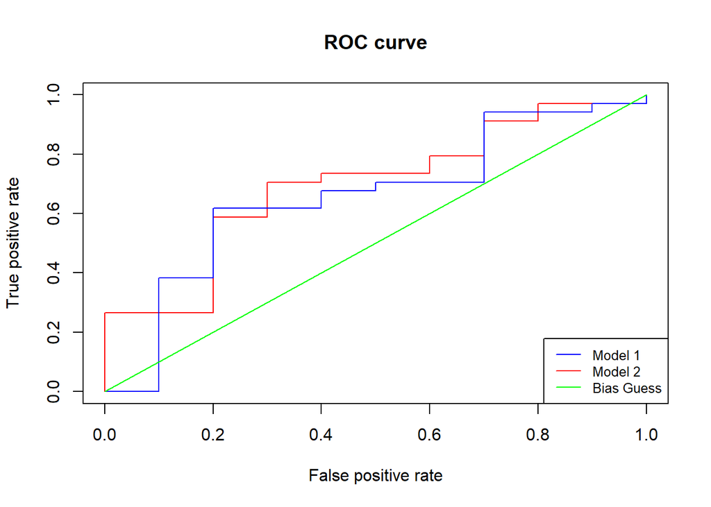

ROC curves compare the performance of two predictive models. Both Model 1 and Model 2 exhibit similar abilities in distinguishing between classes, as indicated by their overlapping curves. No single model significantly outperforms either other; both show improved predictive power than random chance (represented by diagonal line). Both true positive rates increase at comparable rates while false positive rates decline with threshold values; suggesting neither model stands out among all others for predictive power within its threshold values range; their closeness to each other in relation to top-left corner indicates balanced sensitivity/specificity balance in both models

```r
print(c(auc, auc2, auc0))
```

```
## [1] 0.6558824 0.6941176 0.5000000
```

##Section 5 Prediction performance on the test sets

In test data set, we pick session 1 from it. We can see the name of the brain area and number of them.

```r
## Test data:
table(test_session[[1]]$brain_area)
```

```
##
##  ACA  CA3   DG   LS  MOs root  SUB VISp
##  109   68   34  139  113   18   75  178
```

```
##  feedback_type decision   avg_spikes
##  -1:28         1:31     Min.   :0.9905
##  1 :72         2:41     1st Qu.:1.2912
##                3:22     Median :1.4680
##                4: 6     Mean   :1.5241
##                         3rd Qu.:1.7851
##                         Max.   :2.2234
```

```r
pred2test <-predict(fit2test,test %>% select(-feedback_type),type='response')
numericPredictions <- ifelse(pred2test > 0.5, 1, -1)
levels(test$feedback_type)
```

```
## [1] "-1" "1"
```

```r
prediction2test <- factor(numericPredictions, levels = c(-1, 1))
accuracy <- mean(prediction2test == test$feedback_type)
print(accuracy)
```

```
## [1] 0.75
```

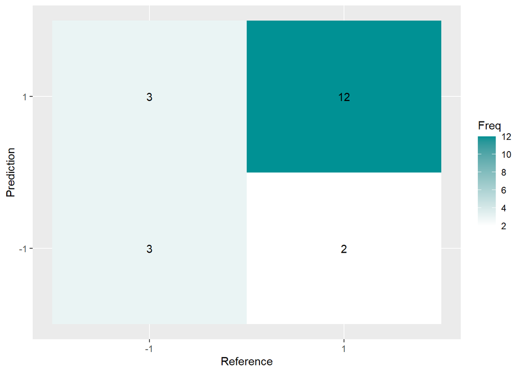

The confusion matrix displays the performance of a binary classification model. It shows both true labels (Reference), and predicted labels (Prediction), each divided into two categories -1 and 1. More correct predictions were made than incorrect ones as demonstrated by larger numbers along the diagonal cells (12 correct predictions for 1 compared to three correct for -1). Off-diagonal cells display errors (3 instances where true -1 was predicted as 1; two instances where true 1 was misclassified as false), with darker shades denoting higher frequency cases and darker shading representing increased frequencies; thus this model appears more accurately at predicting 1 than its counterpart, suggesting greater accuracy over prediction of false -1 cases.

##Section 6 Discussion

The confusion matrix for the binary classifier shows a 75% accuracy rate, which was same with what we tested from the session data (75percent). From this, we assume the model 2 has a good stability. With both true and predicted labels of -1 and 1, this model demonstrates strong predictive accuracy for 1. Most predictions line up perfectly with actual labels - particularly 1 with 12 correct predictions aligning perfectly - misclassifications are reduced with three instances of misclassified as 1 instances misclassified as -1; two incorrect predictions from this indicate some bias in favor of 1 as opposed to -1 predictions from this model.The model’s performance is moderate, we think there are more for improvement.

## Reference

Chatgpt

Course Project Consulting, Milestone II

Course Project demo 1

Course Project demo 2

Steinmetz, N.A., Zatka-Haas, P., Carandini, M. et al. Distributed coding of choice, action and engagement across the mouse brain. Nature 576, 266–273 (2019). https://doi.org/10.1038/s41586-019-1787-x

Chen, T., & Guestrin, C. (2016). XGBoost: A Scalable Tree Boosting System. Proceedings of the 22nd ACM SIGKDD International Conference on Knowledge Discovery and Data Mining.

Allaire, JJ, Yihui Xie, Jonathan McPherson, Javier Luraschi, Kevin Ushey, Aron Atkins, Hadley Wickham, Joe Cheng, Winston Chang, and Richard Iannone. 2018. rmarkdown: Dynamic Documents for R. https://rmarkdown.rstudio.com.